# Airline On-Time Presentation

## by Yusuf Abdulganiyu

## Investigation Overview

In this investigation, I wanted to look at the characteristics of the major causes of delay for both arrival and departure. Also, to have a look at the monthly trend for the maximum delays duration over the years.

## Dataset Overview

This dataset reports flights in the United States, including carriers, arrival and departure delays, and reasons for delays, from 2004 to 2008.

## Distribution of Arrival delays

The arrival delay dataset takes on a range of values, between -40 and 300. Delays are values falling at a range greater than 0. Plotted on a hist plot, the distribution of arrival delays is unimodal and skewed to the right.

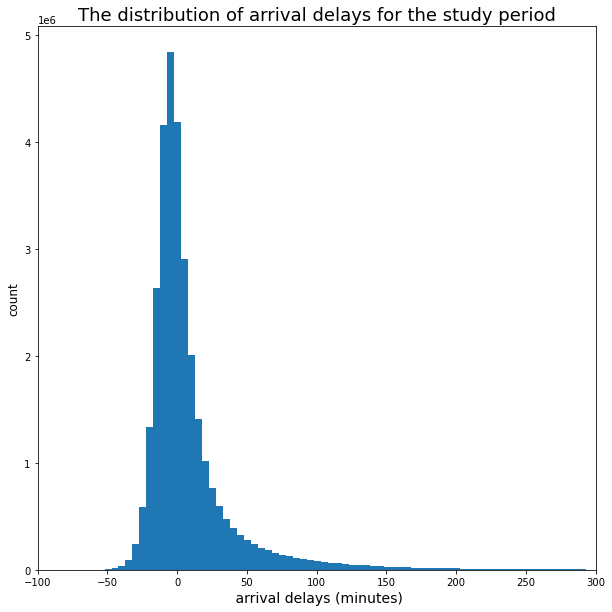

## Distribution of Departure delays

Unlike the arrival delay, the departure delay dataset takes on range of values, between -25 and 250. Plotted on a hist plot, the distribution of departure delays is unimodal and also skewed to the right.

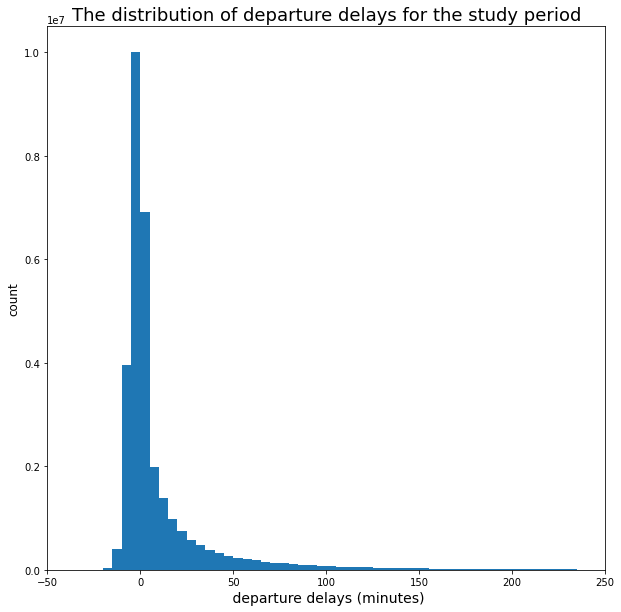

## Departure delay vs Arrival delay

Plotting departure delay against arrival delay, taking a sample of n = 500, using a scatter plot, produces a linear positive relationship, of about 91% between arrival and departure delays.

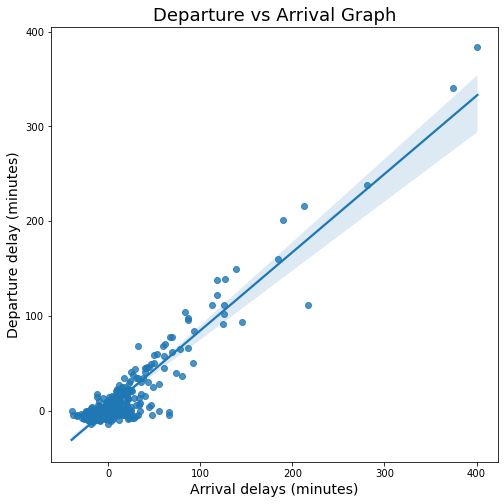

## Monthly trends of maximum delays duration

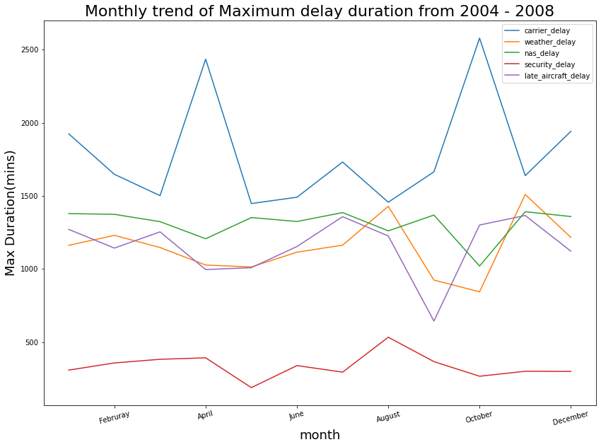